# Introdução à Ciência de Dados

Bacharelado em Administração

Prof. Washington Santos da Silva

IFMG - Campus Formiga

9 de abril de 2025

## Diário de Bordo

**O que vimos até hoje?**

- Aula 1 ✅
  - Introdução e Contextualização ✅
  - O que é Ciência de Dados? ✅
  - Papéis Profissionais na Área de Dados ✅
  - Áreas de Aplicações ✅
  - Habilidades Interpessoais e Analíticas ✅
  - Apresentação da Disciplina ✅
- Aula 2 ✅
  - Metodologia CRISP-DM ✅
  - Tipos de Análise ✅
    - Descritiva ✅
    - Diagnóstica ✅
    - Preditiva ✅
    - Prescritiva ✅
  - Configurações: Git/GitHub ✅
- Aula 3 ✅
  - Introdução ao RStudio ✅
    - Criação do **seu** Projeto RStudio da Disciplina ✅
- Aula 4 ✅
  - Introdução ao Git e GitHub ✅
    - Criação do **seu** repositório do projeto RStudio da disciplina no GitHub ✅

## Nesta Aula: Ferramentas para Ciência de Dados

**Tópicos**

- Breve Revisão do IDE RStudio
- Introdução ao Sistema de Publicação Quarto:
- Sessão Prática Guiada com Relatório 1
  - Execução dos comandos git essenciais

## Nesta Aula: Ferramentas para Ciência de Dados

**Resultados Esperados**

Ao final da aula espero que vocês:

1. Sintam-se mais confortáveis com o IDE RStudio
2. Entendam a estrutura **básica** de um arquivo quarto e como personalizá-lo
3. Sejam capazes de **renderizar** um arquivo quarto (.qmd)
4. Saibam **atualizar** o repositório local do seu projeto RStudio e **sincronizá-lo** com o GitHub

**Diretrizes para Aulas Mais Produtivas**

🔊 **Mantenha conversas em volume baixo**

⌨️ **Código com método:**

95% dos erros são evitáveis com:

- Atenção na digitação
- Respeitar a sequência lógica de etapas
- Revisão antes de pedir ajuda

🤝 **Inteligência colaborativa:**

- Compartilhe conhecimento
- Resolva questões técnicas simples com colegas próximos
- Reserve ao professor as dúvidas conceituais complexas

💪 **Capacidade de Resolver Problemas**

Cada erro resolvido é uma evolução da sua habilidade analítica

## Ausentes - Última Aula (e Outras)

**Custo da Ausência**

- Não será possível dedicar mais tempo de aula para repetir os passos de criação do projeto RStudio e repositório no GitHub.
- **Todo o passo a passo está detalhado nos slides da Aula 4** (incluindo comandos e prints).

**Recomendo:**

- **Hoje:**
  - Acompanhe a aula com um colega que já criou o repositório **ou**
  - Participe com **máxima atenção** para não perder novos conteúdos.
- **Depois:**
  - Execute os passos dos slides da Aula 4 (*sem pular etapas*).
- **Dúvidas?**
  - Consulte colegas primeiro.
  - Me procure **após a aula** apenas se já tiver tentado seguir os slides.

# Breve Revisão do IDE RStudio

## O que é o RStudio?

**Um Ambiente de Desenvolvimento Integrado (*Integrated Development Environment*, IDE)**

- IDE que suporta múltiplas linguagens (R, Python, SQL, C++…), mas é especialmente útil para a linguage R
- Facilita a escrita de código, gerenciamento de projetos, criação de documentos computacionais (arquivos quarto, scripts, notebooks…)
- Integra ferramentas para desenvolvimento, depuração e publicação

## Interface do RStudio

**Painel Superior Esquerdo:** - Editor de código - Documentos Quarto (`.qmd`) - Scripts R (`.R`)

**Painel Inferior Esquerdo:** - **Console** R (execução de comandos R) - **Terminal** (acesso ao sistema operacional)

*Painel Superior Direito:* - Ambiente (variáveis e objetos) - Histórico de comandos - Conexões - Git (controle de versão)

**Painel Inferior Direito:** - **Arquivos** - **Pacotes** - Ajuda - **Visualização** (documentos html)

## Instalação de Pacotes R

**Usando a Guia Packages**

Para instalar pacotes usando a guia **Packages** no RStudio:

- Clique na guia **Packages**.
- Clique em **Install Packages**.
- Digite o nome de cada pacote que deseja instalar separados por um espaço ou vírgula na caixa de texto, ou copie os pacotes abaixo e cole na caixa de texto:

```r
tidyverse here usethis fs
```

## Console vs Terminal no RStudio

### Console

- Ambiente de execução da linguagem **R**
- Interpreta comandos R diretamente
- Para análises interativas

### Terminal

- Interface para o **sistema operacional**
- Executa comandos do shell (Git Bash, PowerShell, etc.)
- Acesso a Git, pip, npm e outras ferramentas
- Permite navegação pelo sistema de arquivos

## Projetos RStudio

**O que são projetos RStudio?**

- Unidades organizacionais para seu trabalho
- Cada projeto tem sua própria pasta
- Facilita a organização de arquivos relacionados
- Permite integração com controle de versão (Git)

## Etapas para Criar um Projeto RStudio com Git/GitHub

**Etapas para Criar um Projeto RStudio com Git**

1. Criar repositório (vazio) no GitHub
2. Clonar o repositório para seu computador
3. Criar o projeto RStudio na pasta clonada

## Criando um projeto RStudio

**Etapa 1: Criar Repositório Vazio no GitHub**

- Acesse sua conta no GitHub: github.com
- Selecione “**Create repository**”
- No campo abaixo de **Repository name**, digite o nome do repositório, ex: “**seunome_icd2025_projeto**”
  - Caso tenha criado um projeto Rstudio na última aula, utilize um nome diferente do projeto que você criou.
  - **NÃO USE** acentos, espaços vazios ou caracteres especiais 😡
- Agora, apenas clique em “**Create repository**”, no canto inferior esquerdo da página.

## Criando um projeto RStudio

**Etapa 2: Clonar Repositório para seu Computador (Windows)**

1. Na página do repositório vazio que você acaba de criar no GitHub
2. Copie o endereço **https** exibido
3. Abra o Windows Explorer e entre na pasta onde você irá guardar a pasta do repositório que vamos clonar
   - Computadores do Laboratório: pasta Downloads (recomendada)
   - Notebook Próprio: alguns criaram a pasta github na última aula, se sim, entre nesta pasta.
4. Clique com o botão direito do mouse em um espaço vazio desta pasta e selecione “**Git Bash Here**” (Caso necessário, clique em Mais opções)
5. No terminal Git Bash que abrir, digite `git clone`, espaço, e cole o endereço do repositório que você criou clicando no botão direito do mouse e em *Paste*:

```bash
git clone https://github.com/mariasilva/seunome_icd2025_projeto.git
```

## Criando um projeto RStudio

[figure not shown]

1. Clique no menu Project: Canto Superior Direito

## Criando um projeto RStudio

[figure not shown]

2. Escolha *Existing Directory*

## Criando um projeto RStudio

[figure not shown]

3. Clique em Browse, encontre e clique na pasta do repositório clonado e em Create Project

## RStudio: Atalhos de Teclado Úteis

[output not shown]

## Guia de Consulta Rápida (Resumão)

- [Guia de Consulta Rápida sobre RStudio](https://rstudio.github.io/cheatsheets/rstudio-ide.pdf)

# Introdução ao Sistema de Publicação Quarto

## O que é o sistema de publicação Quarto?

**Definição**

- É um sistema de publicação científica e técnica de código aberto que une **texto narrativo** e **código** para produzir documentos elegantemente formatados.
- Com o Quarto, você pode criar diversos produtos:
  - Relatórios (html, pdf, docx )
  - Apresentações (RevealJS, Beamer,…)
  - Dashboards, websites, blogs e livros

## O que é o sistema de publicação Quarto?

[figure not shown]

Figura 1: Sistema Quarto: um formato, diversos produtos.

## Como funciona o Quarto?

**Definição**

- Quando você renderiza um arquivo Quarto (que possui a extensão `.qmd`) contendo código R, primeiro o pacote [knitr](https://yihui.org/knitr/) da linguagem R executa todas as células de código R e cria um novo arquivo markdown (`.md`), que inclui o código e sua saída.
- O arquivo markdown gerado é então processado pelo programa [pandoc](https://pandoc.org), que gera o formato escolhido.
- O botão `Render` do Rstudio encapsula essas ações e as executa na ordem correta para você.

## Sistema Quarto e RStudio

**Integração com RStudio**

No RStudio, você pode criar e editar arquivos Quarto facilmente:

- **File → New File → Quarto Document**
- Botão **“Render”** para renderizar o arquivo.

## Por que usar o sistema Quarto?

**Principais benefícios**

- **Reprodutibilidade**: Documenta todo o processo de análise de dados, garantindo que seu trabalho possa ser reproduzido.
- **Integração de código e narrativa**: Combina texto explicativo, código e resultados em um único documento.
- **Múltiplos formatos de saída**: Gera diferentes formatos (html, pdf, docs, apresentações) a partir do mesmo arquivo fonte.
- **Atualizações automáticas**: Ao modificar dados ou código, basta renderizar o documento para atualizar todos os resultados.

## Anatomia de um Arquivo Quarto

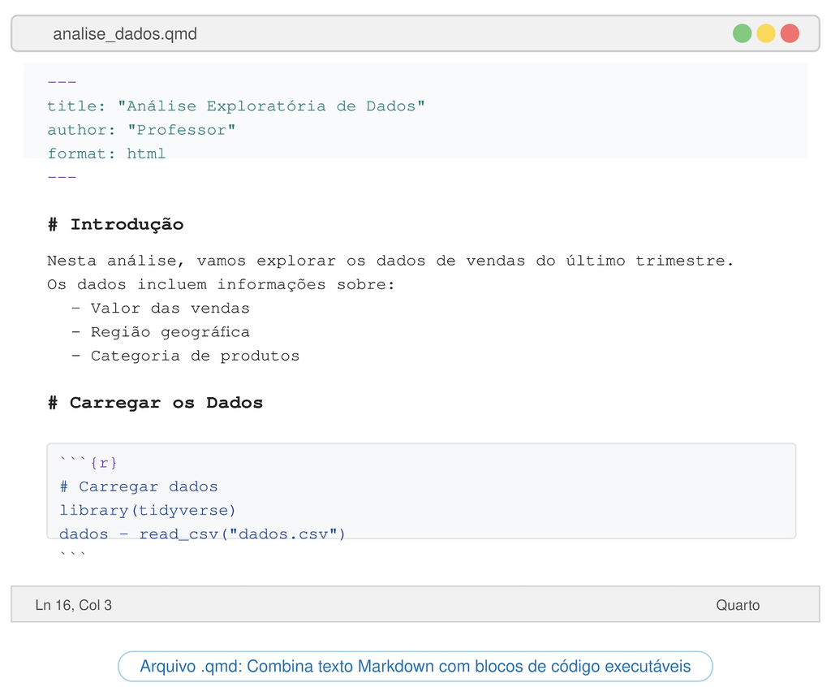

## Anatomia de um Arquivo Quarto

**Nota**

Um arquivo Quarto (`.qmd`) consiste de três elementos fundamentais:

1. **Metadados** (YAML): Controla o formato e opções do documento
2. **Texto** em Markdown: O conteúdo narrativo do documento
3. **Células de Código**: Código executável com suas opções